# GSC-1790 Filtering - MirMaster Raw Data

#### 18 samples + count of at least 4: eDat6

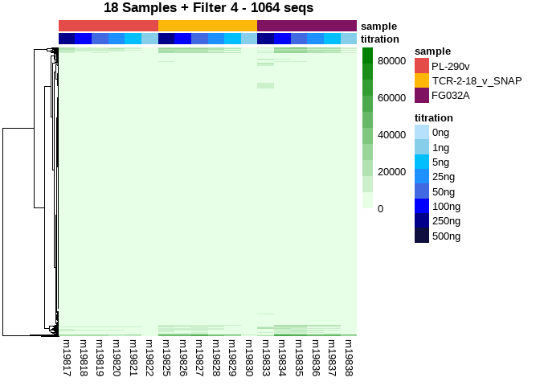

```r
eDat6 %>%
  pheatmap(main = "18 Samples + Filter 4 - 1064 seqs", cluster_cols = FALSE, show_colnames = TRUE, show_rownames = FALSE, annotation_col = pDat[c("titration", "sample")], annotation_colors = my_colour, color = hmcol)
```

#### 18 samples + count of at least 1 in all: eDat3

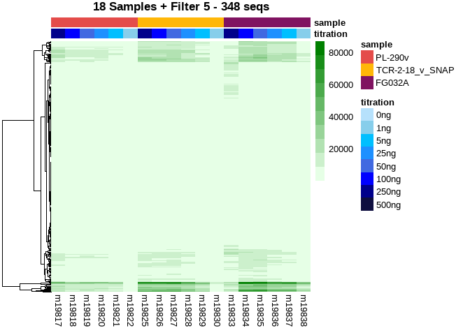

```r
eDat3 %>%
  pheatmap(main = "18 Samples + Filter 5 - 348 seqs", cluster_cols = FALSE, show_colnames = TRUE, show_rownames = FALSE, annotation_col = pDat[c("titration", "sample")], annotation_colors = my_colour, color = hmcol)
```

I think I’ll recode `eDat3` wherein if expression is equal to:

| Expression | Category |
| --- | --- |
| 1 | 1 |
| 1 - 10 | 2 |
| 10 - 100 | 3 |
| 100 - 1000 | 4 |
| > 1000 | 5 |

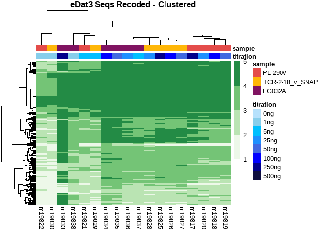

```r
eDat3_cat <- eDat3 %>%
  mutate_all(funs(
    case_when(
    . == 1 ~ "1",
    between(., 1, 10)  ~ "2",
    between(., 10, 100)  ~ "3",
    between(., 10, 1000)  ~ "4",
    . > 1000  ~ "5"))
  )

eDat3_cat <- eDat3_cat %>%
  mutate_if(is.character, as.numeric)

eDat3_cat %>%
  pheatmap(main = "eDat3 Seqs Recoded - Clustered", show_colnames = TRUE, show_rownames = FALSE, annotation_col = pDat[c("titration", "sample")], annotation_colors = my_colour, color = brewer.pal(4, "Greens"))
```

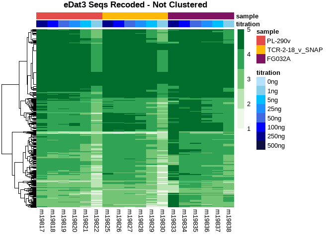

```r
eDat3_cat %>%
  pheatmap(main = "eDat3 Seqs Recoded - Not Clustered", show_colnames = TRUE, show_rownames = FALSE, annotation_col = pDat[c("titration", "sample")], cluster_cols = FALSE, annotation_colors = my_colour, color = brewer.pal(5, "Greens"))
```

#### Recoding eDat

I think I’ll do the same recoding for eDat, however I’ll have to introduce another category:

| Expression | Category |
| --- | --- |
| 0 | 0 |
| 1 | 1 |
| 1 - 10 | 2 |
| 10 - 100 | 3 |
| 100 - 1000 | 4 |
| > 1000 | 5 |

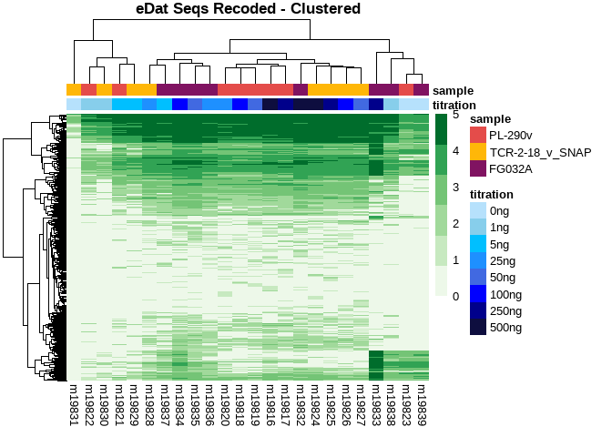

```r
eDat_cat <- eDat %>%
  mutate_all(funs(
    case_when(
    . == 0 ~ "0",
    . == 1 ~ "1",
    between(., 1, 10)  ~ "2",
    between(., 10, 100)  ~ "3",
    between(., 10, 1000)  ~ "4",
    . > 1000  ~ "5"))
  )

eDat_cat <- eDat_cat %>%
  mutate_if(is.character, as.numeric)

eDat_cat %>%
  pheatmap(main = "eDat Seqs Recoded - Clustered", show_colnames = TRUE, show_rownames = FALSE, annotation_col = pDat[c("titration", "sample")], annotation_colors = my_colour, color = brewer.pal(6, "Greens"))
```

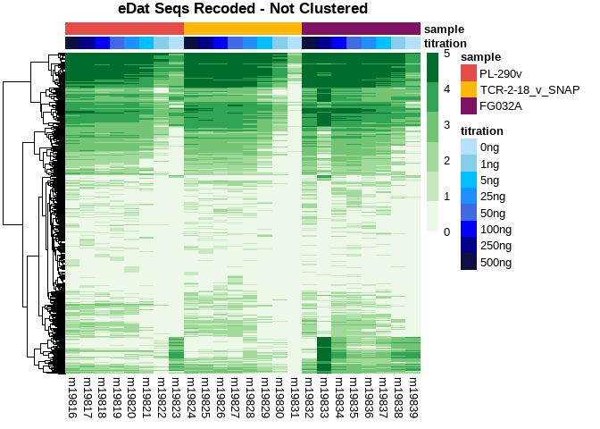

```r
eDat_cat %>%
  pheatmap(main = "eDat Seqs Recoded - Not Clustered", show_colnames = TRUE, show_rownames = FALSE, annotation_col = pDat[c("titration", "sample")], cluster_cols = FALSE, annotation_colors = my_colour, color = brewer.pal(6, "Greens"))
```

#### Rob Lab T1

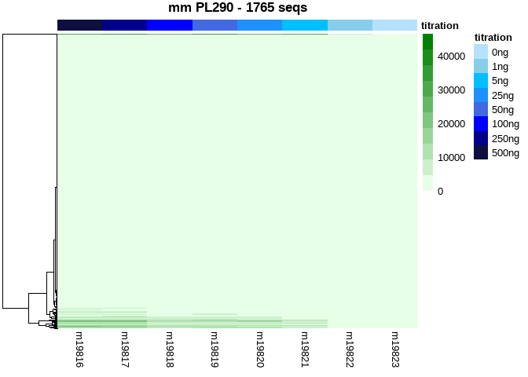

```r
eDat_s1 %>%
  pheatmap(main = "mm PL290 - 1765 seqs", clustering_distance_cols = "euclidean", clustering_method = "complete", show_colnames = TRUE, show_rownames = FALSE, annotation_col = pDat_s1, annotation_colors = my_colour, color = hmcol, cluster_cols = FALSE)
```

#### Rob Lab Term

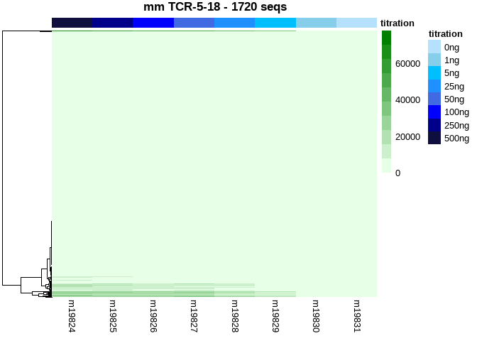

```r
eDat_s2 %>%
  pheatmap(main = "mm TCR-5-18 - 1720 seqs", clustering_distance_cols = "euclidean", clustering_method = "complete", show_colnames = TRUE, show_rownames = FALSE, annotation_col = pDat_s2, annotation_colors = my_colour, color = hmcol, cluster_cols = FALSE)
```

#### GSC Control

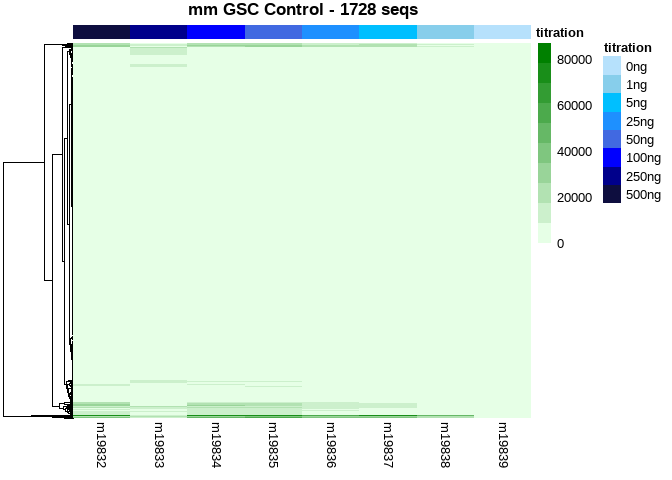

```r
eDat_con %>%
  pheatmap(main = "mm GSC Control - 1728 seqs", clustering_distance_cols = "euclidean", clustering_method = "complete", show_colnames = TRUE, show_rownames = FALSE, annotation_col = pDat_con, annotation_colors = my_colour, color = hmcol, cluster_cols = FALSE)
```

## **6.0 0ng**

### All 3 Samples

```r
mm_zero <- eDat[c(8,16,24)]

#seqs with at leat 1 count in 1 of the 3 samples
mm_zero_all <- mm_zero %>%
  rownames_to_column(var = "miRNA") %>%
  mutate(Sum = rowSums(.[2:4])) %>%
  filter(Sum >= 1) %>%
  column_to_rownames(var = "miRNA") %>%
  dplyr::select(-Sum)

#seqs with at least 1 count in all 3 samples
mm_zero <- mm_zero %>%
  rownames_to_column(var = "miRNA") %>% #keeping only seqs which have a count of 1 or more
  filter_all(all_vars(. >= 1))  %>%
  column_to_rownames(var = "miRNA")

nrow(mm_zero) #178
```

```
## [1] 178
```

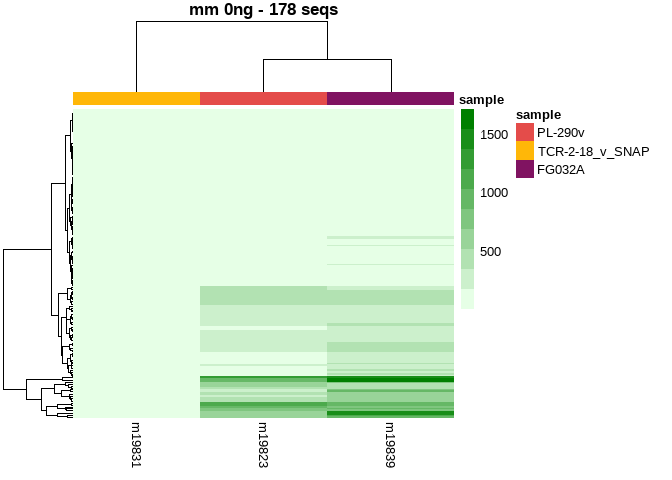

```r
#str(mm_zero)

pDat_zero <- pDat %>%
  filter(titration == "0ng")
pDat_zero <- pDat_zero[c(2)]

mm_zero %>%
  pheatmap(main = "mm 0ng - 178 seqs", clustering_distance_cols = "euclidean", clustering_method = "complete", show_colnames = TRUE, show_rownames = FALSE, annotation_col = pDat_zero, annotation_colors = my_colour, cluster_rows = TRUE, color = hmcol)
```

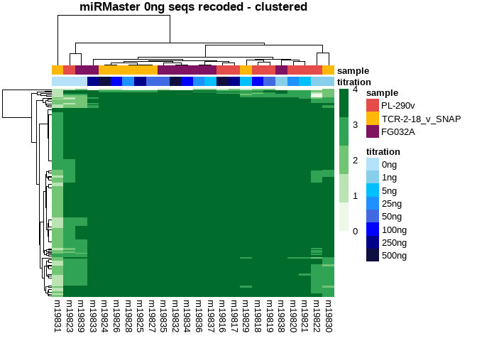

```r
#Recoding 0ng

mm_map <- as.data.frame(rownames(mm_zero))
colnames(mm_map) [1] <- "miRNA"

eDat <- eDat %>%
  rownames_to_column(var = "miRNA")

mm_map <- mm_map %>%
  inner_join(eDat, by = "miRNA")

eDat <- eDat %>%
  column_to_rownames(var = "miRNA")

mm_map <- mm_map %>%
  column_to_rownames(var = "miRNA") %>%
  mutate_if(is.character, as.numeric)

#str(mm_map)

mm_map <- mm_map %>%
  mutate_all(funs(
    case_when(
    . == 0 ~ "0",
    . == 1 ~ "1",
    between(., 1, 10)  ~ "2",
    between(., 10, 100)  ~ "3",
    . > 100  ~ "4"))
  )

mm_map <- mm_map %>%
  mutate_if(is.character, as.numeric)

mm_map %>%
  pheatmap(main = "miRMaster 0ng seqs recoded - clustered", show_colnames = TRUE, show_rownames = FALSE, annotation_col = pDat[c("titration", "sample")], annotation_colors = my_colour, color = brewer.pal(5, "Greens"))
```

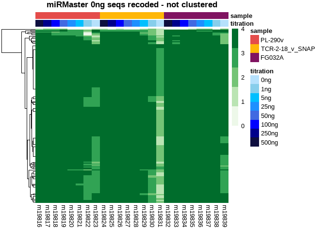

```r
mm_map %>%
  pheatmap(main = "miRMaster 0ng seqs recoded - not clustered", show_colnames = TRUE, show_rownames = FALSE, annotation_col = pDat[c("titration", "sample")], cluster_cols = FALSE, annotation_colors = my_colour, color = brewer.pal(5, "Greens"))
```

### By Sample Basis

```r
s1_zero <- eDat[c(8)]

s1_zero_1  <- s1_zero  %>%
  rownames_to_column(var = "miRNA") %>%
  filter(s1_zero[,1] >= 1) %>%
  column_to_rownames(var = "miRNA")
nrow(s1_zero_1) #689
```

```
## [1] 689
```

```r
#seqs with at atleast 10 counts - as per GSC's table
s1_zero_10  <- s1_zero  %>%
  rownames_to_column(var = "miRNA") %>%
  filter(s1_zero[,1] >= 10) %>%
  column_to_rownames(var = "miRNA")

nrow(s1_zero_10) #576
```

```
## [1] 576
```

```r
colSums(s1_zero_10) #85823
```

```
## m19823
##  85823
```

```r
s2_zero <- eDat[c(16)]

s2_zero_1  <- s2_zero  %>%
  rownames_to_column(var = "miRNA") %>%
  filter(s2_zero[,1] >= 1) %>%
  column_to_rownames(var = "miRNA")
nrow(s2_zero_1) #182
```

```
## [1] 182
```

```r
#seqs with at atleast 10 counts - as per GSC's table
s2_zero_10  <- s2_zero  %>%
  rownames_to_column(var = "miRNA") %>%
  filter(s2_zero[,1] >= 10) %>%
  column_to_rownames(var = "miRNA")
nrow(s2_zero_10) #59
```

```
## [1] 59
```

```r
colSums(s2_zero_10) #1934
```

```
## m19831
##   1934
```

```r
con_zero <- eDat[c(24)]

con_zero_1  <- con_zero  %>%
  rownames_to_column(var = "miRNA") %>%
  filter(con_zero[,1] >= 1) %>%
  column_to_rownames(var = "miRNA")
nrow(con_zero_1) #721
```

```
## [1] 721
```

```r
#seqs with at atleast 10 counts - as per GSC's table
con_zero_10  <- con_zero  %>%
  rownames_to_column(var = "miRNA") %>%
  filter(con_zero[,1] >= 10) %>%
  column_to_rownames(var = "miRNA")
nrow(con_zero_10) #592
```

```
## [1] 592
```

```r
colSums(con_zero_10) #103886
```

```
## m19839
## 103886
```

### Comparing with GSC Numbers

Now, comparing with the GSC and the numbers they got:

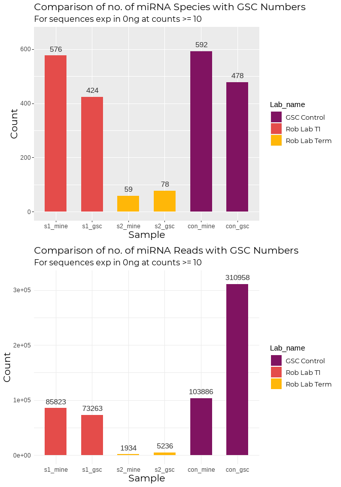

```r
gsc_compare <- as.data.frame(c("miRNA species at\n >= 10 counts", "Reads aligned"))

gsc_compare <- gsc_compare %>%
  mutate(count = 6) %>%
  uncount(count)

gsc_compare$Sample <- factor(c("s1_mine", "s2_mine", "con_mine", "s1_gsc", "s2_gsc", "con_gsc"), levels = c("s1_mine", "s1_gsc", "s2_mine", "s2_gsc", "con_mine", "con_gsc"))

gsc_compare$Count <- c(nrow(s1_zero_10), nrow(s2_zero_10), nrow(con_zero_10), as.numeric(424), as.numeric(78), as.numeric(478), colSums(s1_zero_10), colSums(s2_zero_10), colSums(con_zero_10), as.numeric(73263),as.numeric(5236), as.numeric(310958))

colnames(gsc_compare) [1] <- "Value"

gsc_compare <- gsc_compare %>%
  mutate(Lab_name =
           case_when(
             str_detect(Sample, "s1") ~ "Rob Lab T1",
             str_detect(Sample, "s2") ~ "Rob Lab Term",
             str_detect(Sample, "con") ~ "GSC Control"
           ))

compare_species <- gsc_compare[1:6, ]
compare_reads <- gsc_compare[7:12, ]

g3 <- compare_species %>%
  ggplot(aes(x = Sample, y = Count, fill = Lab_name)) +
  geom_bar(stat = "identity", width = 0.6) +
  geom_text(aes(label = Count), vjust = -0.8, colour = "#333333") +
  scale_fill_manual(values = col_samp) +
  coord_cartesian(y = c(0, 650)) +
  my_theme_2 +
  labs(title = "Comparison of no. of miRNA Species with GSC Numbers ", subtitle = "For sequences exp in 0ng at counts >= 10")

g4 <- compare_reads %>%
  ggplot(aes(x = Sample, y = Count, fill = Lab_name)) +
  geom_bar(stat = "identity",  width = 0.6) +
  geom_text(aes(label = Count), vjust = -0.8, colour = "#333333") +
  scale_fill_manual(values = col_samp) +
  coord_cartesian(y = c(0, 320000)) +
  my_theme +
  labs(title = "Comparison of no. of miRNA Reads with GSC Numbers ", subtitle = "For sequences exp in 0ng at counts >= 10")

ggarrange(g3, g4)
```

For the 576 seqs that show up in Rob Lab T1, let’s check their expression.

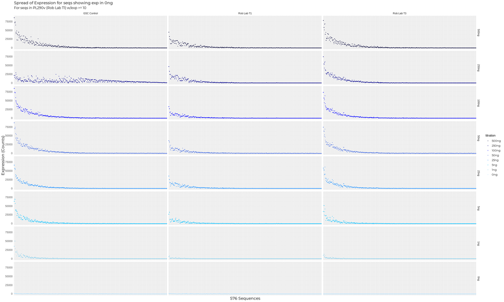

```r
eDat <- eDat %>%
  rownames_to_column(var = "miRNA")

pDat <- pDat %>%
  rownames_to_column(var = "ID")

s1_10_seqs <- as.data.frame(rownames(s1_zero_10))

colnames (s1_10_seqs) [1] <- "miRNA"

s1_10_seqs <- s1_10_seqs %>%
  inner_join(eDat, by = "miRNA") %>%
  column_to_rownames(var = "miRNA")

s1_10_zero_seqs <- melt(as.matrix(s1_10_seqs))

s1_10_zero_seqs <- s1_10_zero_seqs %>%
  inner_join(pDat, by = c ("Var2" = "ID"))

s1_10_zero_seqs$titration <- factor(s1_10_zero_seqs$titration, levels = c("500ng", "250ng", "100ng", "50ng", "25ng", "5ng", "1ng", "0ng"))

col_titra <- c(`0ng` = "#b6e1fc", `1ng` = "#87CEEB",
        `5ng` = "#00BFFF", `25ng` = "#1E90FF", `50ng` = "#4169E1",
        `100ng` = "#0000FF", `250ng` = "#00008B", `500ng` = "#0e0e3f")

s1_10_zero_seqs %>%
  ggplot(aes(x = reorder(Var1, -value), y = value, colour = titration)) +
  geom_point(size = 0.8) +
  my_theme +
  scale_color_manual(values = col_titra) +
  theme(axis.text.x = element_blank()) +
  labs(title = "Spread of Expression for seqs showing exp in 0ng", subtitle = "For seqs in PL290v (Rob Lab T1) w/exp >= 10", x = "576 Sequences", y = "Expression (Counts)") +
  facet_grid(titration ~ Lab_name) +
  my_theme +
  theme(axis.text.x = element_blank())
```

I’m now going to subtract the avg exp of the 0ng from all 3 samples

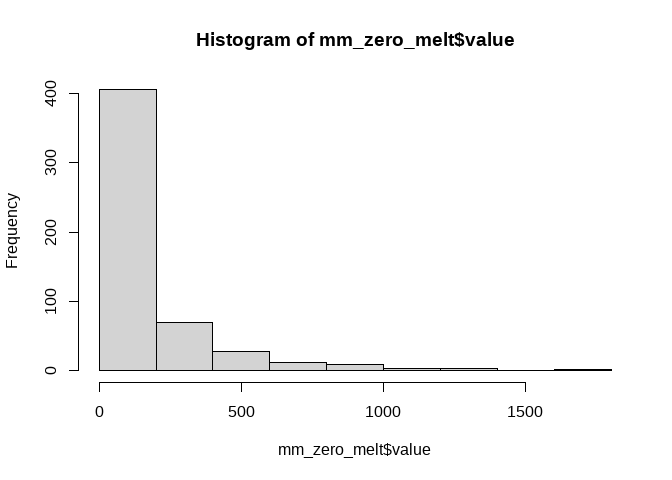

```r
mm_zero_melt <-  melt(as.matrix(mm_zero)) #in order to keep rownames

hist(mm_zero_melt$value)
```

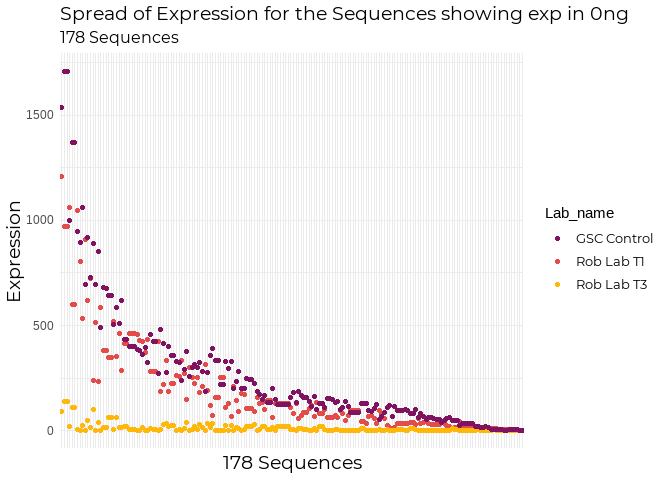

```r
mm_zero_melt <- mm_zero_melt %>%
  mutate(Lab_name =
           case_when(
             Var2 == "m19823" ~ "Rob Lab T1",
             Var2 == "m19831" ~ "Rob Lab T3",
             Var2 == "m19839" ~ "GSC Control"
           )
         )

mm_zero_melt %>%
  ggplot(aes(x = reorder(Var1, -value), y = value, colour = Lab_name)) +
  geom_point() +
  scale_color_manual(values = col_samp) +
  my_theme +
  theme(axis.text.x = element_blank()) +
  labs(title = "Spread of Expression for the Sequences showing exp in 0ng", subtitle = "178 Sequences", x = "178 Sequences", y = "Expression")
```

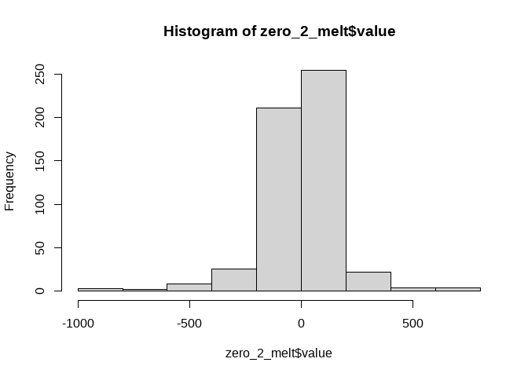

```r
#Get means on 0ng exp across all 3 samples
mm_zero <- mm_zero %>%
  mutate(avg = apply(mm_zero, 1, mean))


mm_zero <- mm_zero %>%
  mutate(s1_sub = m19823 - avg) %>%
  mutate(s2_sub = m19831 - avg) %>%
  mutate(con_sub = m19839 - avg)

zero_2 <- mm_zero [c(5:7)]

zero_2_melt <-  melt(as.matrix(zero_2)) #in order to keep rownames

hist(zero_2_melt$value)
```

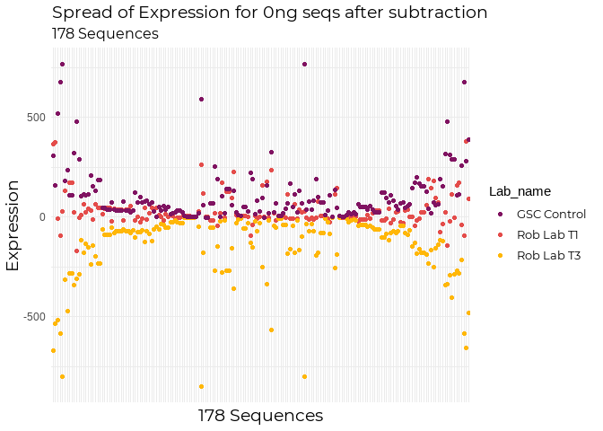

```r
zero_2_melt <- zero_2_melt %>%
  mutate(Lab_name =
           case_when(
             Var2 == "s1_sub" ~ "Rob Lab T1",
             Var2 == "s2_sub" ~ "Rob Lab T3",
             Var2 == "con_sub" ~ "GSC Control"
           )
         )

zero_2_melt %>%
  ggplot(aes(x = reorder(Var1, -value), y = value, colour = Lab_name)) +
  geom_point() +
  my_theme +
  scale_color_manual(values = col_samp) +
  theme(axis.text.x = element_blank()) +
  labs(title = "Spread of Expression for 0ng seqs after subtraction", subtitle = "178 Sequences", x = "178 Sequences", y = "Expression")
```